# Assignment 3

Reuven Herzog

9/26/2020

# Tel Aviv Data

## Intro

I’m exploring some data about the city of Tel Aviv. Tel Aviv is the cultural and economic capital of Israel. It is also the hub of the non-traditionally Jewish lifestyles in Israel. I had been hoping to explore data from the classically Jewish (e.g. synagogues) and the modern, “Tel Avivi” sides (e.g. yoga studios). Unfortunately, the municipal data wasn’t so conducive to that quest, so this will be not as thematically perfect, but still interesting.

Loading data from the Tel Aviv municipality’s open data portal. Layer codes obtained here: “https://opendata.tel-aviv.gov.il/OpenData_Ducaments/%D7%9E%D7%90%D7%92%D7%A8%D7%99%20%D7%9E%D7%99%D7%93%D7%A2%20GIS.pdf” 1) Neighborhoods, polygon data 2) Parks and green space, polygon data 3) Synagogues, point data 4) Art galleries, point data

```r
get_TLVData <- function(code) {
    url = paste0("https://gisn.tel-aviv.gov.il/GisOpenData/service.asmx/GetLayer?layerCode=",code,"&layerWhere=&xmin=&ymin=&xmax=&ymax=&projection=")
    return(st_read(url, quiet = TRUE))
}

shuls <- get_TLVData(568)
neighborhoods <- get_TLVData(511) %>%
  left_join(read.csv(file = "TLV neighborhoods with english.csv"), by = 'oid_shchuna')
parks <- get_TLVData(551)
galleries <- get_TLVData(601)
```

Let’s start by visualizing the Tel Aviv neighborhoods, and each of these sets on their own, before we get to analysis.

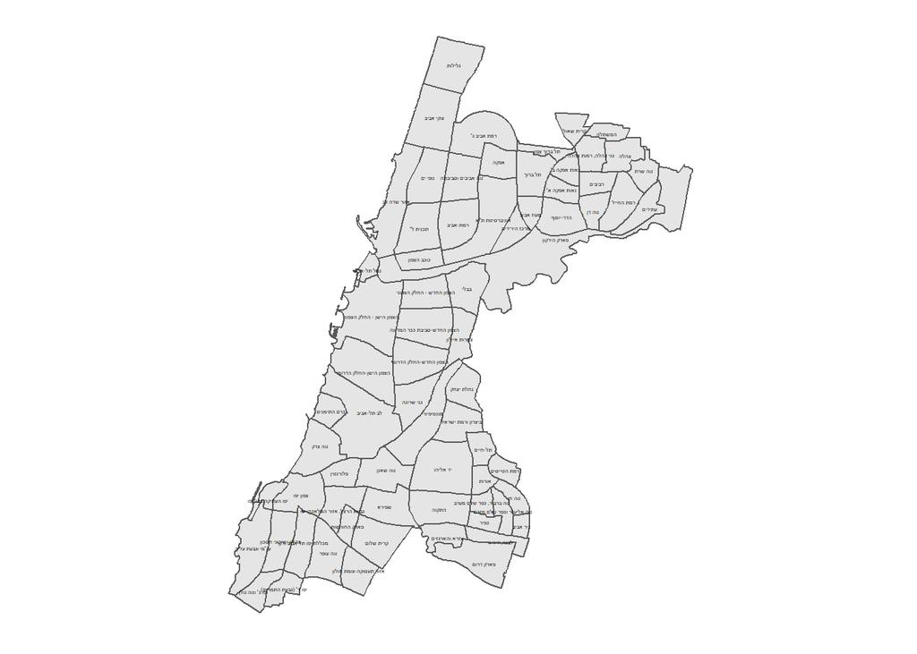

```r
ggplot(neighborhoods) +
  geom_sf() +
  geom_sf_text(label = neighborhoods$shem_shchuna, size = 1) +
  theme_map()
```

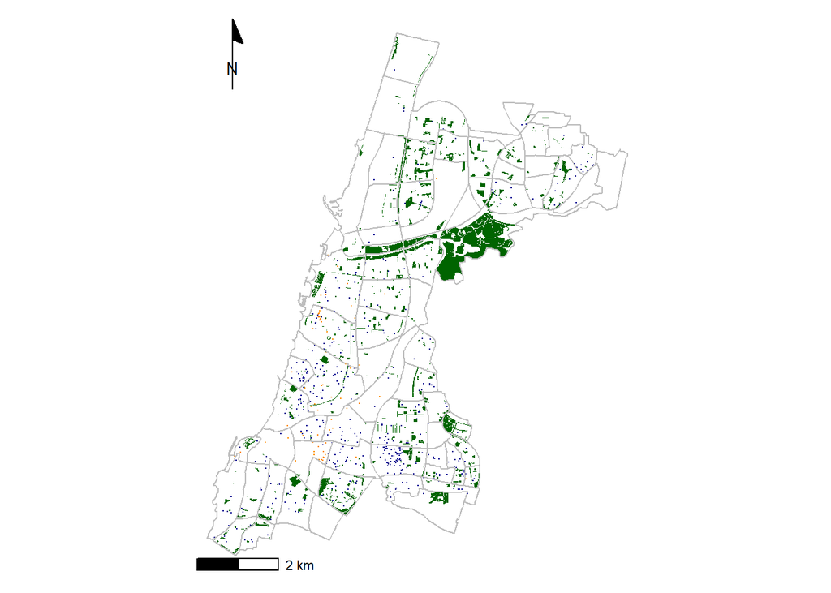

```r
ggplot(parks) +
  geom_sf(fill = "darkgreen", color = NA) +
  geom_sf(data = shuls, color = "blue4", size = 0.01) +
  geom_sf(data = galleries, color = "darkorange", size = 0.01) +
  geom_sf(data= neighborhoods, fill = NA, color = "gray") +
  scale_color_discrete() +
  theme_map() +
  annotation_scale() +
  annotation_north_arrow(location = "tl", style = north_arrow_minimal())
```

I can’t figure out why a legend isn’t appearing…

## Simple Point-in-Polygon Analysis

Let’s make a table with each neighborhood’s name and how many synagogues and art galleries are in it.

```r
shul_covers = st_covers(neighborhoods, shuls)
neighborhoods <- neighborhoods %>%
  mutate(num_shuls = lengths(shul_covers))

art_covers = st_covers(neighborhoods, galleries)
neighborhoods <- neighborhoods %>%
  mutate(num_art = lengths(art_covers))
```

```r
tidy_table <- select(neighborhoods, eng_name, num_shuls, num_art)
st_geometry(tidy_table) = NULL
tidy_table
```

```
##                              eng_name num_shuls num_art
## 1                        Sde Dov area         0       0
## 2                         Tzukei Aviv         2       0
## 3                        Ramat Aviv C         2       0
## 4                 Tel Aviv University         1       1
## 5                       Kochav Tzafon         2       0
## 6        Neve Avivim and surroundings         4       0
## 7                          Ramat Aviv         5       0
## 8                    Merkaz Hayeridim         0       0
## 9                           Nofei Yam         2       0
## 10                            Plan 30         2       0
## 11                              Bavli         3       0
## 12                       Kiryat Shaul         2       0
## 13                        Hamashtelah         0       0
## 14       Ganei Tzahala, Ramot Tzahala         0       0
```

[output cut: 57 more lines]

(For later - figure out how to get this to print Hebrew characters instead of the unicode numbers. Edit: I gave up and translated the neighborhood names to English)

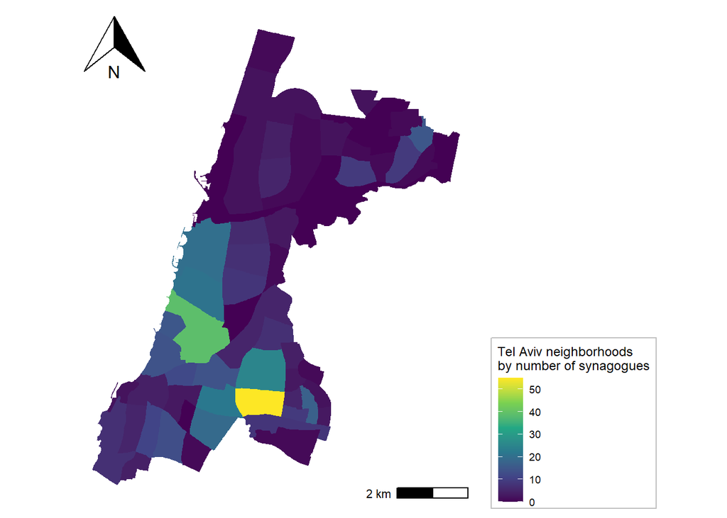

```r
ggplot(neighborhoods) +
  geom_sf(color = NA,
          aes(fill = num_shuls)) +
  scale_fill_viridis_c(name = "Tel Aviv neighborhoods\nby number of synagogues") +
  annotation_scale(location = "br") +
  annotation_north_arrow(location = "tl") +
theme_map() +
  theme(legend.background = element_rect(fill = alpha("white", 0.5),
                                         color = "gray")) +
  theme(legend.position = "right")
```

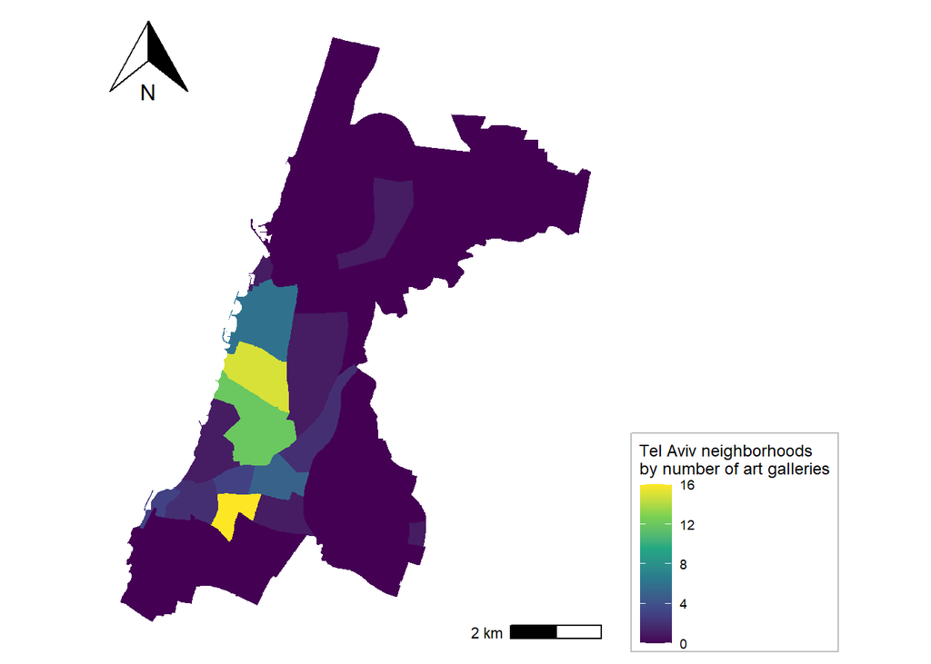

```r
ggplot(neighborhoods) +
  geom_sf(color = NA,
          aes(fill = num_art)) +
  scale_fill_viridis_c(name = "Tel Aviv neighborhoods\nby number of art galleries") +
  annotation_scale(location = "br") +
  annotation_north_arrow(location = "tl") +
theme_map() +
  theme(legend.background = element_rect(fill = alpha("white", 0.5),
                                         color = "gray")) +
  theme(legend.position = "right")
```

Note that these two graphs are scaled relative to themselves: They show concentrations in different neighborhoods, but in general the number of synagogues in an area is greater than the number of art galleries. Note the greater concentration of synagogues in the southern and eastern neighborhoods, and the much higher concentration of galleries in the old center of Tel Aviv.

We will now compare these two more directly:

## Comparative Maps

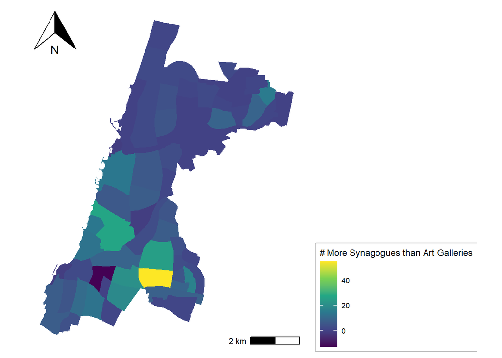

```r
neighborhoods <- neighborhoods %>%
  mutate(diff = num_shuls - num_art, pct_diff = num_shuls / (num_shuls + num_art))

ggplot(neighborhoods) +
  geom_sf(color = NA,
          aes(fill = diff)) +
  scale_fill_viridis_c(name = "# More Synagogues than Art Galleries") +
  annotation_scale(location = "br") +
  annotation_north_arrow(location = "tl") +
theme_map() +
  theme(legend.background = element_rect(fill = alpha("white", 0.5),
                                         color = "gray")) +
  theme(legend.position = "right")
```

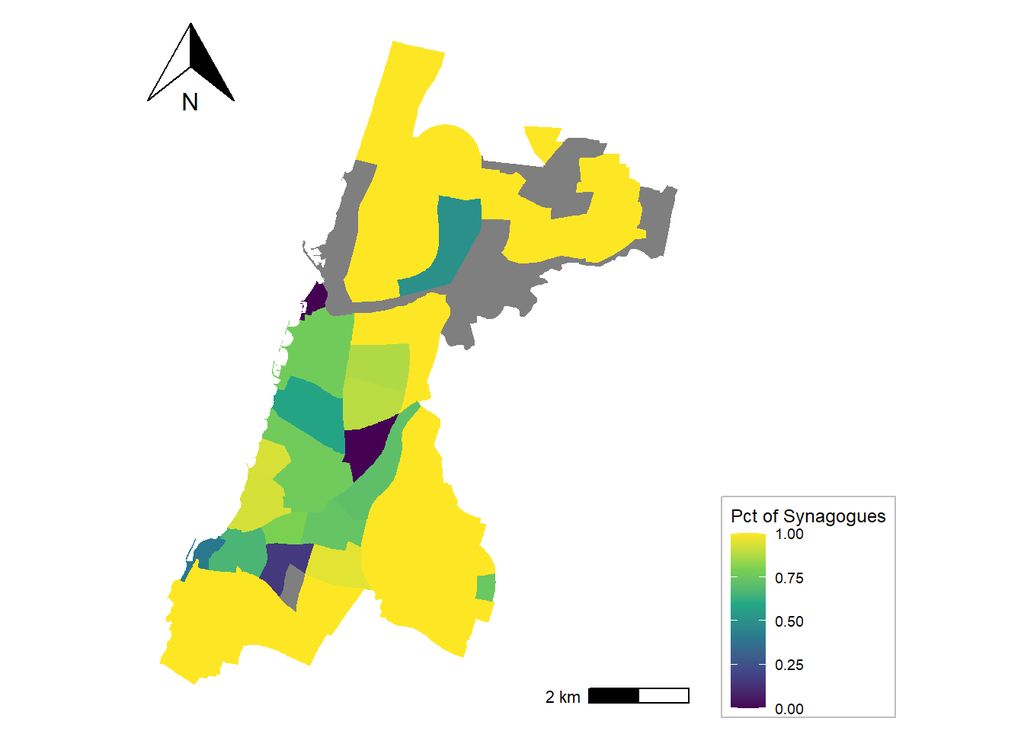

```r
neighborhoods <- neighborhoods %>%
  mutate(diff = num_shuls - num_art, pct_diff = num_shuls / (num_shuls + num_art))

ggplot(neighborhoods) +
  geom_sf(color = NA,
          aes(fill = pct_diff)) +
  scale_fill_viridis_c(name = "Pct of Synagogues") +
  annotation_scale(location = "br") +
  annotation_north_arrow(location = "tl") +
theme_map() +
  theme(legend.background = element_rect(fill = alpha("white", 0.5),
                                         color = "gray")) +
  theme(legend.position = "right")
```

I need to find better palettes to illustrate this more clearly. But the second map is particularly telling that synagogues tend to dominate art galleries, except in the central neighborhoods - and even then they generally outnumber them. At large this makes sense - there are 481 synagogues in the city, to 71 galleries. Given this, where galleries even challenge synagogues makes a statement about the character of the neighborhood. There are a very few neighborhoods where galleries even outnumber synagogues:

```r
neighborhoods <- neighborhoods %>%
  mutate(more_art = diff < 0)
heathenlands <- neighborhoods[neighborhoods$more_art == TRUE,] %>%
  select(eng_name, num_shuls, num_art, diff)
st_geometry(heathenlands) = NULL
heathenlands
```

```
##                        eng_name num_shuls num_art diff
## 21                Tel Aviv Port         0       1   -1
## 31                 Ganei Sarona         0       1   -1
## 36    Ancient Jaffa, Jaffa Port         2       3   -1
## 64 Givat Herzl, Jaffa Work Area         3      16  -13
```

## Parks and Green Space

Let’s start by wondering if there are any synagogues or art galleries inside of parklands.

```r
parks <- parks %>%
  mutate(num_shuls = lengths(st_covers(parks, shuls)),
         num_art = lengths(st_covers(parks, galleries)),
         has_shuls = num_shuls > 0, has_art = num_art > 0)
paste0("Number of parks that contain synagogues: ",sum(parks$has_shuls))
```

```
## [1] "Number of parks that contain synagogues: 14"
```

```r
paste0("Proportion of all parks: ",sum(parks$has_shuls)/length(parks$oid_shetach)*100,"%")
```

```
## [1] "Proportion of all parks: 1.4%"
```

```r
paste0("Number of parks that contain art galleries: ",sum(parks$has_art))
```

```
## [1] "Number of parks that contain art galleries: 0"
```

OK, now that we know 14 of the 1000 green spaces contain synagogues, let’s see where they are.

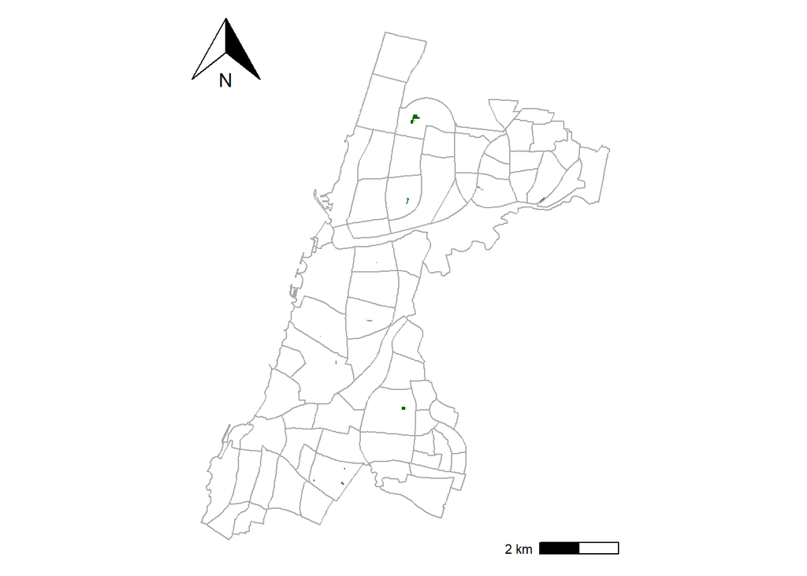

```r
park_with_shul <- parks[parks$has_shuls == TRUE,]

ggplot(park_with_shul) +
  geom_sf(fill = 'darkgreen', color = NA) +
  geom_sf(data = neighborhoods, color = "darkgray", fill = NA) +
  annotation_north_arrow(location = 'tl') +
  annotation_scale(location = 'br') +
  theme_map()
```

We can see from this map that all the “parks” are more appropriately described as small green spaces, or gardens. (If I printed the chart with the “type of park” column this would be explicit, but I don’t want to deal with more Hebrew text issues right now.)

## A Prayer and a Painting

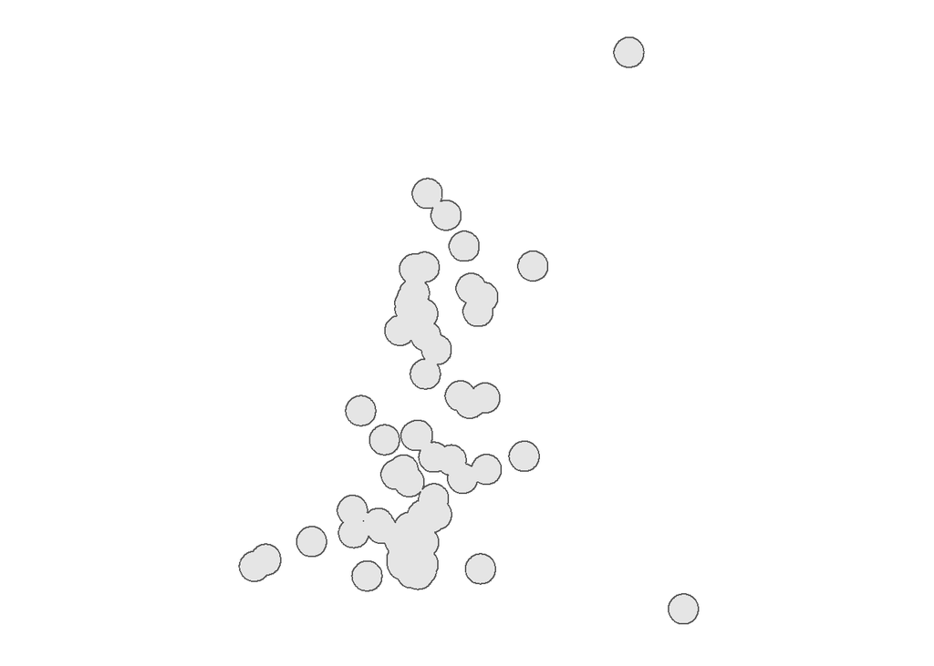

```r
art_buffer <- st_buffer(galleries, dist = 200) %>% st_union()
ggplot(art_buffer) +
  geom_sf() +
  theme_map()
```

Honestly, this is some pretty good abstract art!

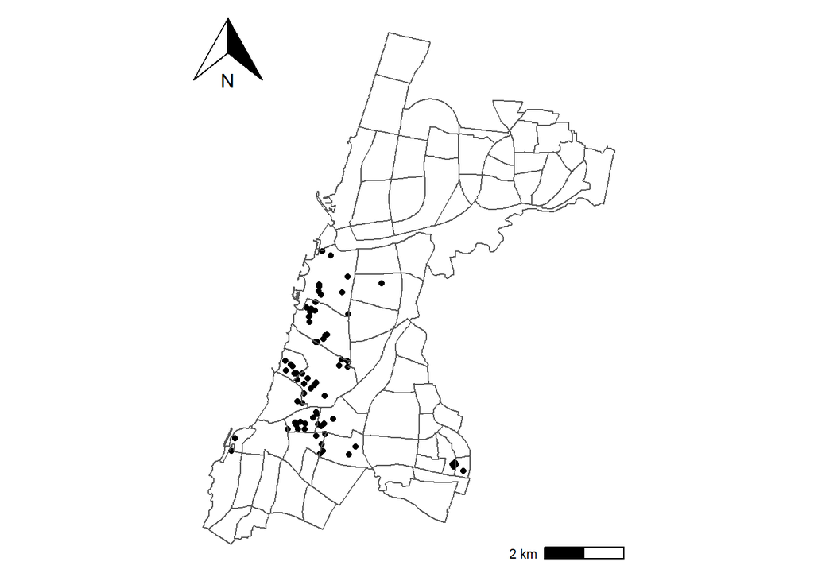

```r
syn_art <- shuls[art_buffer,]

ggplot(syn_art) +
  geom_sf() +
  geom_sf(data = neighborhoods, fill = NA) +
  annotation_north_arrow(location = 'tl') +
  annotation_scale(location = 'br') +
  theme_map()
```

```r
paste("Number of synagogues within 200 m of an art gallery:", length(syn_art$name_bet_cneset))
```

```
## [1] "Number of synagogues within 200 m of an art gallery: 76"
```

# Polygon-in-Polygon

```r
# remove duplicate parks
parks_unique <- st_difference(parks)

parks_nhood <- parks_unique %>%
  st_join(neighborhoods) %>%
  select(ms_area, oid_shchuna, eng_name)

st_geometry(parks_nhood) <- NULL

parks_nhood <- parks_nhood %>%
  group_by(eng_name) %>%
  summarise(park_area = sum(ms_area))
neighborhoods <- neighborhoods %>%
  left_join(parks_nhood) %>%
  mutate(park_area = ifelse(is.na(park_area), 0, park_area)) %>%
  mutate(park_area_km2 = park_area/1000000)
```

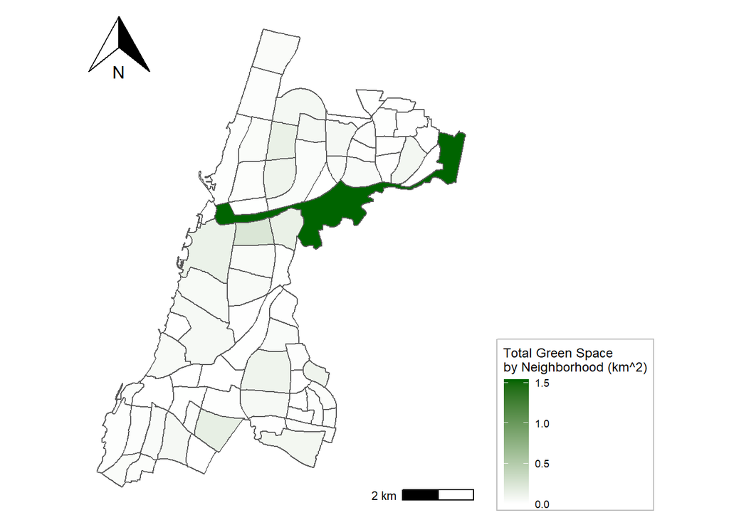

```r
ggplot(neighborhoods, aes(fill = park_area_km2)) +
  geom_sf() +
  scale_fill_continuous(low = "white", high = "darkgreen", name = "Total Green Space\nby Neighborhood (km^2)") +
  annotation_north_arrow(location = 'tl') +
  annotation_scale(location = 'br') +
  theme_map() +
  theme(legend.background = element_rect(fill = alpha("white", 0.5),
                                         color = "gray")) +
  theme(legend.position = "right")
```

OK, so this is … somewhat helpful. The problem is that a full neighborhood is devoted to Yarkon Park - which dominates the scale.

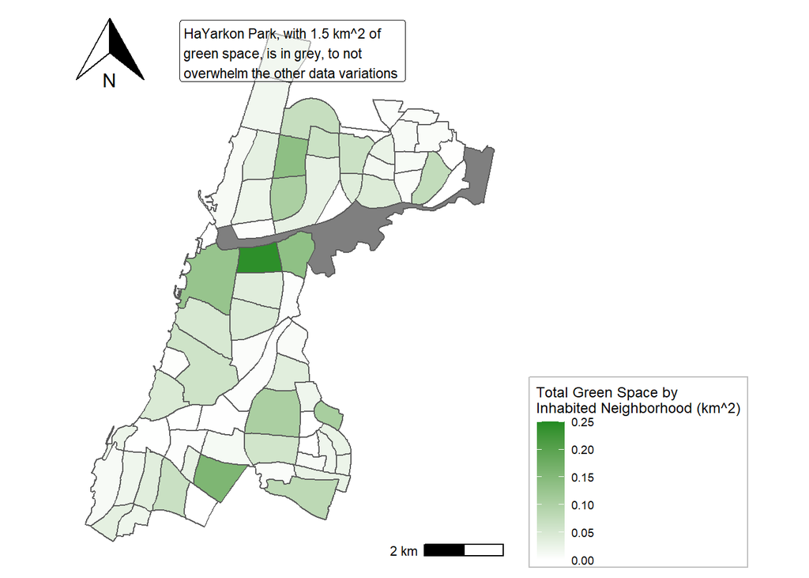

```r
park_plot <- ggplot(neighborhoods, aes(fill = park_area_km2)) +
  geom_sf() +
  scale_fill_gradient(low = "white", high = "forestgreen", name = "Total Green Space by\nInhabited Neighborhood (km^2)", limits = c(0,0.25)) +
  annotation_north_arrow(location = 'tl') +
  annotation_scale(location = 'br') +
  theme_map() +
  theme(legend.background = element_rect(fill = alpha("white", 0.5),
                                         color = "gray")) +
  theme(legend.position = "right") +
  annotate(geom = "label",
           x = st_bbox(neighborhoods)$xmax - 8000, y = st_bbox(neighborhoods)$ymax - 1250,
           label = "HaYarkon Park, with 1.5 km^2 of\ngreen space, is in grey, to not\noverwhelm the other data variations",
           alpha = 0.5,
           hjust = 0, vjust = 0, size = 3)
park_plot
```

We can see here that the neighborhoods with the most green space are the ones immediately to the south of HaYarkon Park. Perhaps this is area near the river, but not technically included in the park polygon. There is also a clear cluster, though not as pronounced as near the park, of the old planned city (south of Yarkon Park, western part of the city), which was planned to have frequent boulevards and open squares.